# 第11講 検定

仮説の正当性をデータから検証する

Published

June 25, 2026

## 準備

以下で利用する共通パッケージを読み込む．

```r
library(conflicted)  # 関数名の衝突を警告
conflicts_prefer(    # 優先的に使う関数を指定
    dplyr::filter(),
    dplyr::select(),
    dplyr::lag(),
    )
library(tidyverse)
#' 日本語を用いるので macOS ではフォントの設定を行う
if(Sys.info()["sysname"] == "Darwin") { # macOS か調べて日本語フォントを指定
    theme_update(text = element_text(family = "HiraginoSans-W4"))
    update_geom_defaults("text", list(family = theme_get()$text$family))
    update_geom_defaults("label", list(family = theme_get()$text$family))}
```

## $t$ 検定の確率シミュレーション

### 問題

適当な正規乱数を用いて確率シミュレーションを考案し，$t$ 検定の過誤について調べなさい．

#### ヒント

例えば適当な数値を指定して以下のような実験を行えばよい．

```r
mc_trial <-
    function(n){
        result <- t.test(rnorm(n,mean = mu0,sd = sd0), mu = mu0)
        return(result$p.value)}
mc_data <-
    replicate(mc, mc_trial(n)) # 1次元配列(ベクトル)が作成される
table(mc_data < alpha)/mc # alpha以下のデータの数(比率)を調べる
```

上記はp値の性質を調べる場合であるが，t統計量についても同様に調べることができる．

### 解答欄

### 解答例

検定統計量の分布を調べるための実験の設定を行う．

```r
n <- 10
mu0 <- 5
sd0 <- 3
mc <- 10000
alpha <- 0.05
mc_trial <-
    function(n, pval = TRUE){
        result <- t.test(rnorm(n, mean = mu0, sd = sd0), mu = mu0)
        if(pval) {
            return(result$p.value)   # p値を取り出す
        } else {
            return(result$statistic) # 検定統計量を取り出す
        }
    }
```

検定統計量の分布を視覚化する．

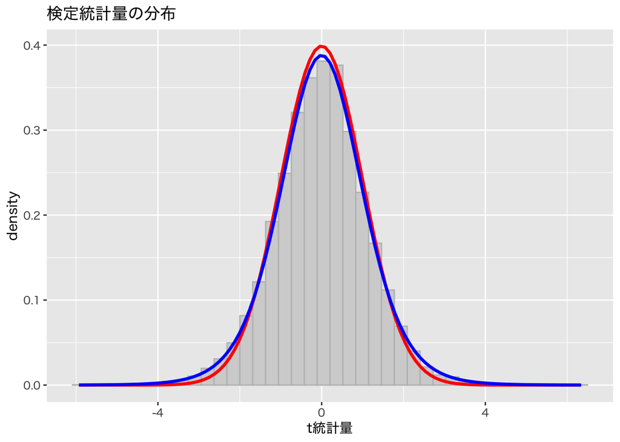

```r
mc_data <-
    replicate(mc, mc_trial(n, pval = FALSE)) |> # 1次元配列(ベクトル)が作成される
    as_tibble_col()
mc_data |>
    ggplot(aes(x = value)) +
    geom_histogram(aes(y = after_stat(density)), # 密度表示
                   bins = 40,
                   fill = "lightgrey",
                   colour = "grey") +
    geom_function(fun = dnorm,      # 正規分布
                  colour = "red",
                  linewidth = 1.2) +
    geom_function(fun = dt,         # 自由度n-1のt分布
                  args = list(df = n-1),
                  colour = "blue",
                  linewidth = 1.2) +
    labs(x = "t統計量", title = "検定統計量の分布")
```

自由度 $n{-}1$ の $t$ 分布が良く当て嵌まることが確認できる．

$p$ 値の分布を見るには以下のようにすればよい．

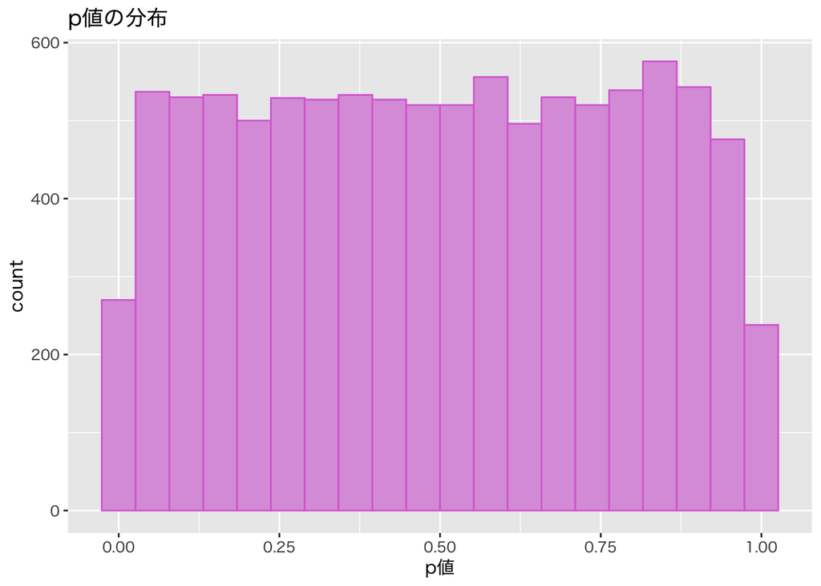

```r
mc_data <-
    replicate(mc, mc_trial(n)) |>
    as_tibble_col()
mc_data |>
    ggplot(aes(x = value)) +
    geom_histogram(bins = 20,
                   fill = "plum",
                   colour = "orchid") +
    labs(x = "p値", title = "p値の分布")
```

```r
mc_data |>
    count(value < alpha) |>
    mutate(prob = n/sum(n)) # alpha以下の結果の数を調べる = サイズ
```

```
# A tibble: 2 × 3
  `value < alpha`     n  prob
  <lgl>           <int> <dbl>
1 FALSE            9480 0.948
2 TRUE              520 0.052
```

$p$ 値は一様に分布し，有意水準と第一種の過誤の関係が確認できる．

一方，帰無仮説が成り立たない場合の p 値の分布は例えば以下のようになる．

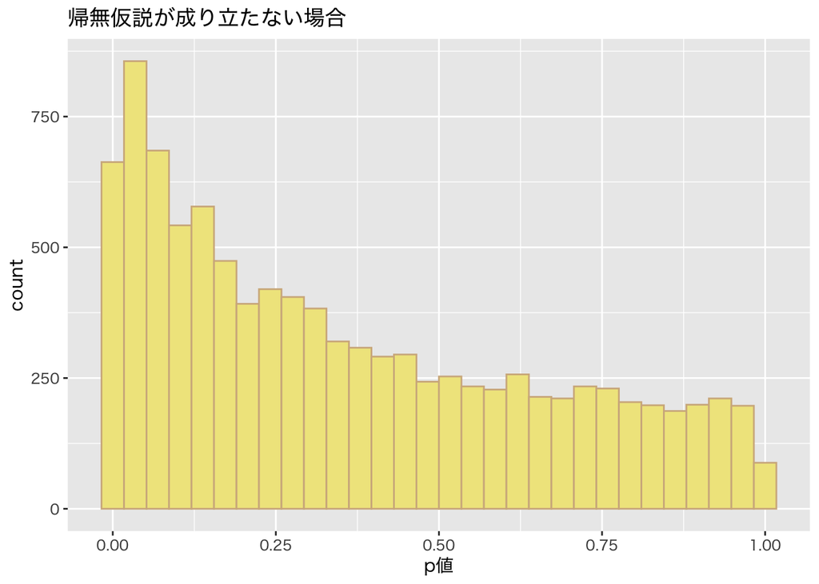

```r
mc_trial <- function(n){
    result <- t.test(rnorm(n, mean = mu0+1, sd = sd0), mu = mu0)
    return(result$p.value)} # p値を取り出す
replicate(mc, mc_trial(n)) |>
    as_tibble_col() |>
    ggplot(aes(x = value)) +
    geom_histogram(fill = "khaki",
                   colour = "tan") +
    labs(x = "p値", title = "帰無仮説が成り立たない場合")
```

$p$ 値は一様に分布しなくなることが確認できる．

たとえば以下のようにすると関数 t.test() で計算される量をまとめて取り出すことができる． まとめて計算できるが，計算が若干重い．

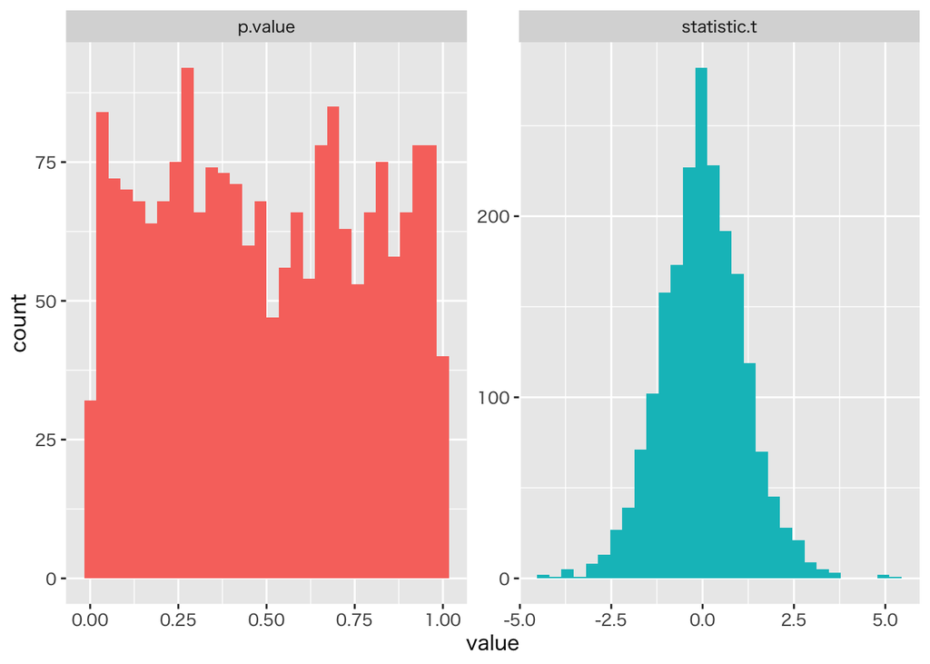

```r
mc_trial <- function(n){
    t.test(rnorm(n, mean = mu0, sd = sd0), mu = mu0) |>
        broom::tidy() |> # tidyverse のパッケージ．様々なオブジェクトを tibble 形式に変換
        select(where(is.numeric)) |> # 数値のみ取り出す
        unlist() # 名前付の数値ベクトルに変換
}
mc <- 2000
replicate(mc, mc_trial(n)) |> # 2次元配列(行列)が作成される
    t() |> as_tibble() |>
    pivot_longer(c(statistic.t, p.value)) |>
    ggplot(aes(x = value, fill = name)) +
    geom_histogram(show.legend = FALSE) +
    facet_wrap(vars(name), ncol = 2, scales = "free") # 横に並べる
```

## 視聴率の検定

### 問題

ある番組の視聴率が2桁に達したかどうか知るために，n人にその番組を観たかどうか確認する． 確率変数
$$\begin{equation}
X_{i}=
\begin{cases}
1,&\text{番組を観た}\\
0,&\text{番組を観ていない}
\end{cases},\;
i=1,2,\dotsc,n
\end{equation}$$
を定義して，これを用いた検定を考えてみよ．

#### ヒント

$X$ の生成は例えば `mu1` を真の視聴率として以下のようにすればよい

```r
x <- sample(0:1, n, replace = TRUE, prob = c(1-mu1,mu1))
```

n人分の視聴結果 {1,0} のベクトルが得られる．

$X$ は正規分布には従わないが， $n$ が大きければ標本平均 $\bar{X}$ は正規分布で十分良く近似できることを利用して良い．

### 解答欄

### 解答例

$X$ は正規分布ではないが，$n$ が十分大きい場合には 区間推定と同様に正規分布(自由度の大きな $t$ 分布)で近似される．

```r
n <- 1000
mu0 <- 0.1 # 越えたい視聴率
mu1 <- 0.11 # 真の視聴率(11%)
x <- sample(0:1, n, replace = TRUE, prob = c(1-mu1,mu1))
table(x)
```

```
x
  0   1
906  94
```

```r
t.test(x,mu = mu0, alternative = "greater")
```

```
    One Sample t-test

data:  x
t = -0.64984, df = 999, p-value = 0.742
alternative hypothesis: true mean is greater than 0.1
95 percent confidence interval:
 0.07879888        Inf
sample estimates:
mean of x
    0.094
```

上記の設定で確率シミュレーションを行う．

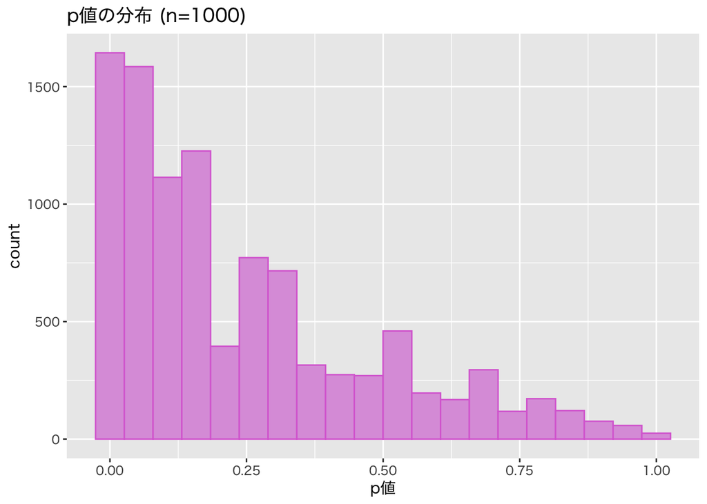

```r
mc <- 10000
alpha <- 0.05 # 自由に設定せよ
mc_trial <-
    function(n){
        x <- sample(0:1, n, replace = TRUE, prob = c(1-mu1,mu1))
        result <- t.test(x, mu = mu0, alternative = "greater")
        return(result$p.value)}
mc_data <-
    replicate(mc, mc_trial(n)) |>
    as_tibble_col()
mc_data |>
    ggplot(aes(x = value)) +
    geom_histogram(bins = 20,
                   fill = "plum",
                   colour = "orchid") +
    labs(x = "p値", title = paste0("p値の分布 (n=",n,")"))
```

```r
table(mc_data < alpha)/mc # alpha以下のデータの数を調べる=検出力
```

```
 FALSE   TRUE
0.7455 0.2545
```

$n$ を変えて実験してみる．

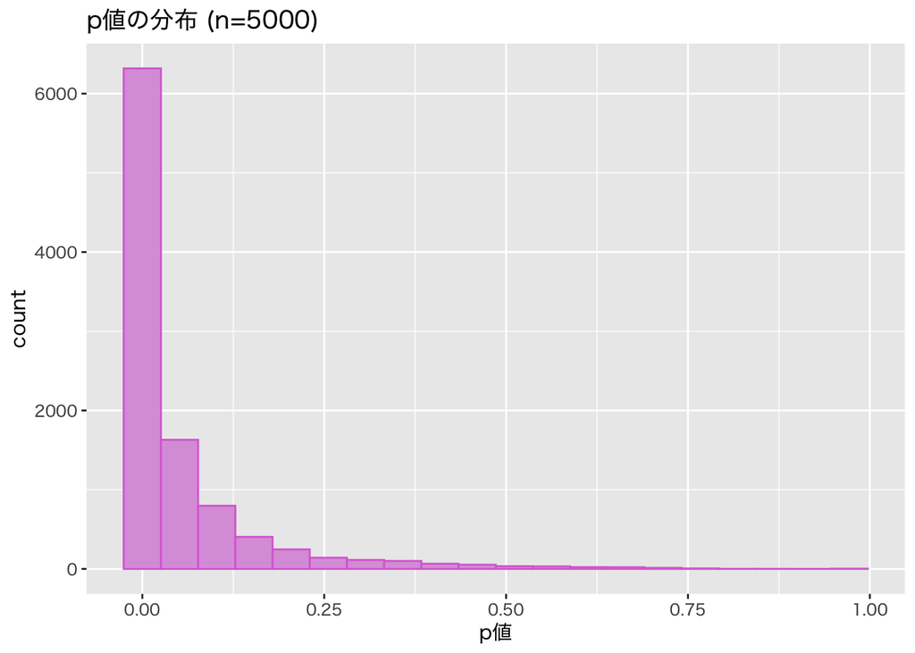

```r
n <- 5000
mc_data <-
    replicate(mc, mc_trial(n)) |>
    as_tibble_col()
mc_data |>
    ggplot(aes(x = value)) +
    geom_histogram(bins = 20,
                   fill = "plum",
                   colour = "orchid") +
    labs(x = "p値", title = paste0("p値の分布 (n=",n,")"))
```

```r
table(mc_data < alpha)/mc # alpha以下のデータの数を調べる=検出力
```

```
FALSE  TRUE
0.259 0.741
```

## 気温の分散の検定

### 問題

東京の気象データの気温の項目を用いて， 6月の気温の分散が， 月毎に計算した気温の分散の平均値より大きいかどうか検定せよ．

#### ヒント

```r
#' データの読み込みを行う
tw_data <- read_csv("data/tokyo_weather.csv")
#' 月毎の気温の分散は以下で計算できる
tw_data |> group_by(month) |> summarize(var(temp))
#' この平均値は以下のように計算される
tw_data |> group_by(month) |>
    summarize(var(temp)) |> pull(`var(temp)`) |> mean()
```

### 解答欄

### 解答例

データの読み込みを行う．

```r
tw_data <-
    read_csv("data/tokyo_weather.csv") |>
    mutate(month = as_factor(month))      # 月毎の表示のために因子化しておく
```

月毎の分布を確認する．

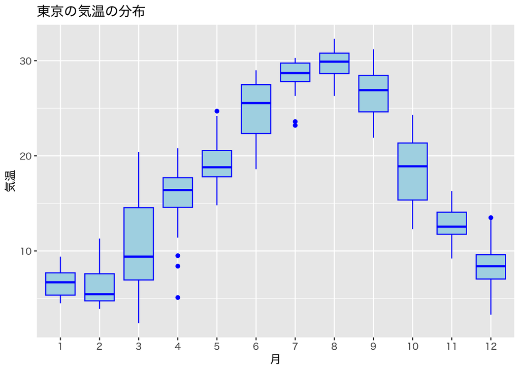

```r
tw_data |>
    ggplot(aes(x = month, y = temp)) +
    geom_boxplot(fill = "lightblue", colour = "blue") +
    labs(x = "月", y = "気温", title = "東京の気温の分布")
```

月毎の分散を計算する．

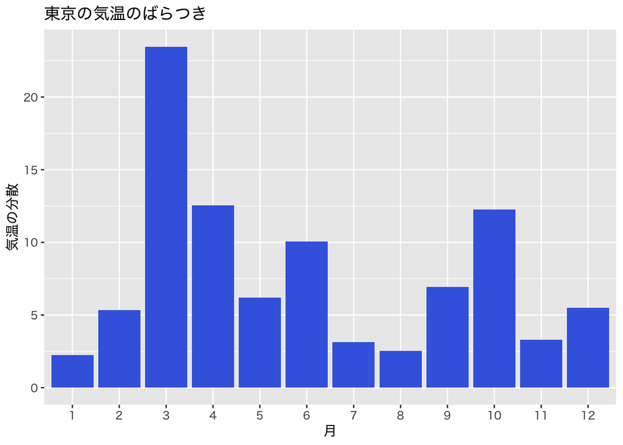

```r
tw_data |>
    group_by(month) |>
    summarize(var = var(temp)) |>
    ggplot(aes(x = month, y = var)) +
    geom_bar(stat = "identity", fill = "royalblue") +
    labs(x = "月", y = "気温の分散", title = "東京の気温のばらつき")
```

関数 `summarize()` は列名を指定しなければ計算内容に``を付けて列名とする．これは “()” が特殊な文字(関数の引数を表す)のためである．

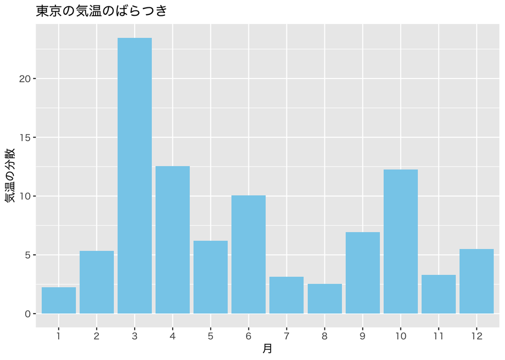

```r
tw_data |>
    group_by(month) |>
    summarize(var(temp)) |>
    ggplot(aes(x = month,
               y = `var(temp)`)) +
    geom_bar(stat = "identity", fill = "skyblue") +
    labs(x = "月", y = "気温の分散", title = "東京の気温のばらつき")
```

検定統計量の計算を行う．

```r
v0 <-
    tw_data |>
    group_by(month) |>
    summarize(var = var(temp)) |>
    pull(var) |>
    mean() # 12ヶ月分の分散の単純な平均
x <-
    tw_data |>
    filter(month == 6) |>    # 6月
    pull(temp)               # 気温のベクトル
(n <- length(x))             # データ数
```

```
[1] 30
```

```r
(chi2 <- (n-1)*var(x)/v0)    # 検定統計量
```

```
[1] 37.37657
```

```r
p0 <- pchisq(chi2, df = n-1)
p0                           # 左片側検定
```

```
[1] 0.8631648
```

```r
1-p0                         # 右片側検定
```

```
[1] 0.1368352
```

```r
2*min(p0,1-p0)               # 両側検定
```

```
[1] 0.2736704
```

分散が小さな8月を検定してみる.

```r
x <-
    tw_data |>
    filter(month == 8) |>    # 8月
    pull(temp)               # 気温のベクトル
(n <- length(x))             # データ数
```

```
[1] 31
```

```r
(chi2 <- (n-1)*var(x)/v0)    # 検定統計量
```

```
[1] 9.749998
```

```r
p0 <- pchisq(chi2, df = n-1)
p0                           # 左片側検定
```

```
[1] 0.0001735228
```

```r
1-p0                         # 右片側検定
```

```
[1] 0.9998265
```

```r
2*min(p0,1-p0)               # 両側検定
```

```
[1] 0.0003470456
```

## 平均の差の検定

### 問題

平均の違いについて考察しなさい．

- 東京の気象データの気温の項目を用いて， 7月と8月の気温の平均が同じかどうか検定しなさい．
- 他の項目や自身の集めたデータでも試してみよ．

### 解答欄

### 解答例

7月と8月の平均気温を比較する．

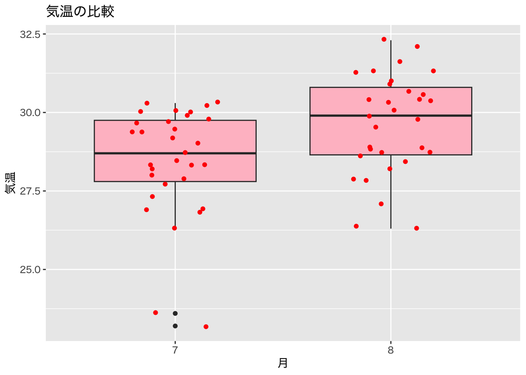

```r
tw_data |>
    filter(month %in% c(7,8)) |> # 月を限定
    ggplot(aes(x = month, y = temp)) +
    geom_boxplot(fill = "pink") +
    geom_jitter(colour = "red", width = 0.2) + # データを重ねて表示
    labs(x = "月", y = "気温", title = "気温の比較")
```

7月と8月の平均気温の差を検定する．

```r
x <- tw_data |> filter(month == 7) |> pull(temp)
y <- tw_data |> filter(month == 8) |> pull(temp)
t.test(x,y)
```

```
    Welch Two Sample t-test

data:  x and y
t = -2.8063, df = 59.329, p-value = 0.00677
alternative hypothesis: true difference in means is not equal to 0
95 percent confidence interval:
 -2.0555581 -0.3444419
sample estimates:
mean of x mean of y
 28.43226  29.63226
```

5月と10月でも試してみる．

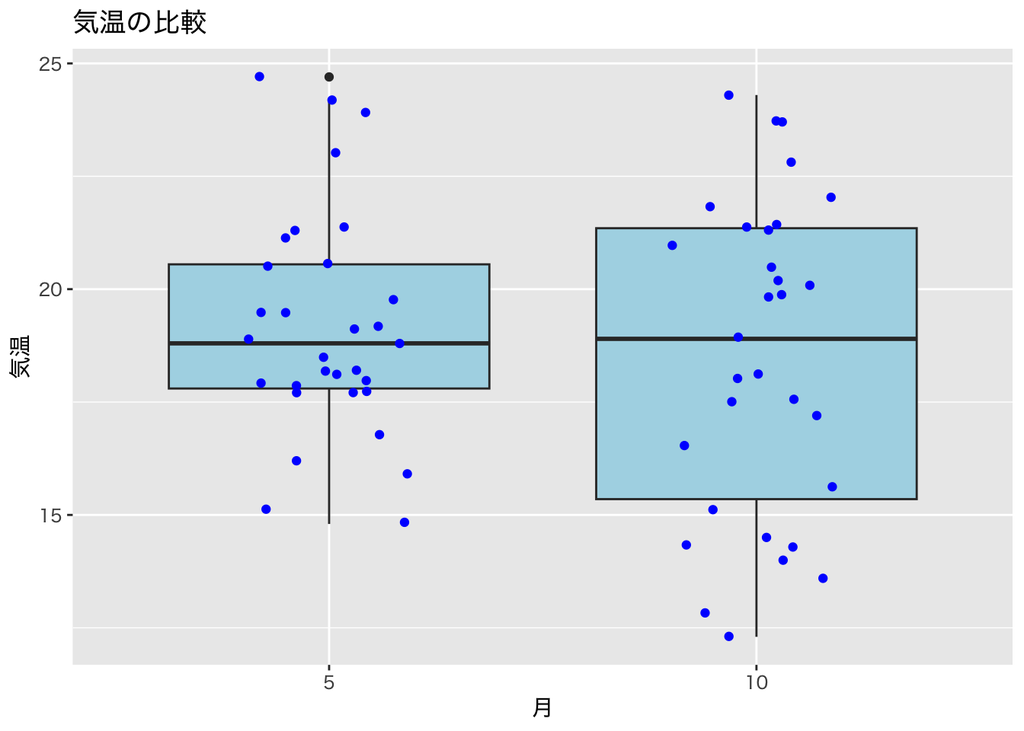

```r
tw_data |>
    filter(month %in% c(5,10)) |>
    ggplot(aes(x = month, y = temp)) +
    geom_boxplot(fill = "lightblue") + # 色を変える
    geom_jitter(colour = "blue", width = 0.2) +
    labs(x = "月", y = "気温", title = "気温の比較")
```

平均気温の差はばらつきより小さく見える．

```r
x <- tw_data |> filter(month == 5) |> pull(temp)
y <- tw_data |> filter(month == 10) |> pull(temp)
t.test(x,y)
```

```
    Welch Two Sample t-test

data:  x and y
t = 0.8359, df = 54.172, p-value = 0.4069
alternative hypothesis: true difference in means is not equal to 0
95 percent confidence interval:
 -0.9021253  2.1924479
sample estimates:
mean of x mean of y
 19.16774  18.52258
```

分布を視覚的に捉えるためには 関数 `geom_jitter()` 以外にもさまざまなパッケージが利用できる． 例えば以下のようなものがある．

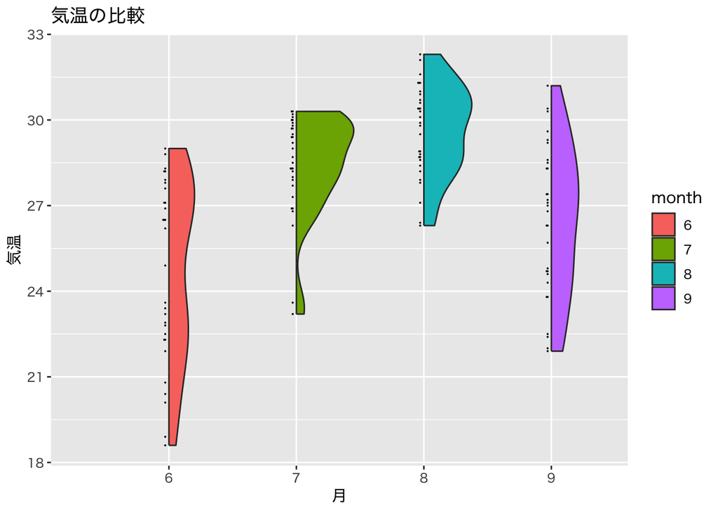

```r
library(see)
tw_data |>
    filter(month %in% 6:9) |>
    ggplot(aes(x = month, y = temp, fill = month)) +
    geom_violindot(fill_dots = "grey") +
    labs(x = "月", y = "気温", title = "気温の比較")
```

## 分散の比の検定

### 問題

分散の違いについて考察しなさい．

- 東京の気象データの気温の項目を用いて， 4月と9月の気温の分散が同じかどうか検定しなさい．
- 他の項目や自身の集めたデータでも試してみよ．

### 解答欄

### 解答例

4月と9月の気温の分散を比較する．

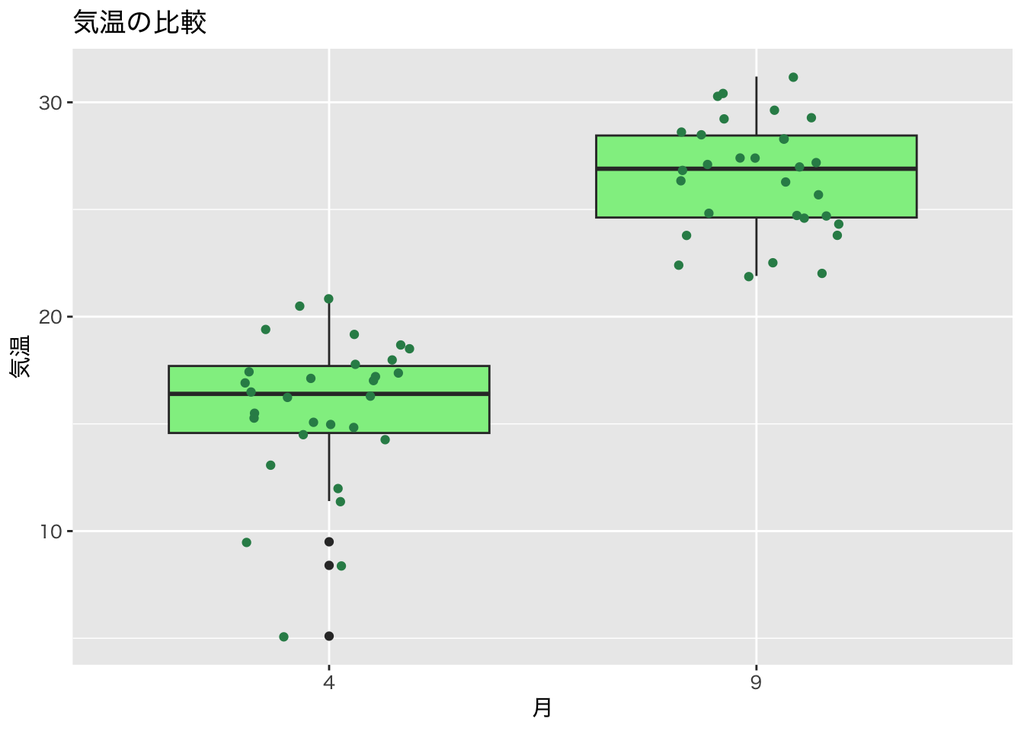

```r
tw_data |>
    filter(month %in% c(4,9)) |>
    ggplot(aes(x = month, y = temp)) +
    geom_boxplot(fill = "lightgreen") + # 色を変える
    geom_jitter(colour = "seagreen", width = 0.2) +
    labs(x = "月", y = "気温", title = "気温の比較")
```

平均気温は大きく異なるがばらつきは同等のように見える．

```r
x <- tw_data |> filter(month == 4) |> pull(temp)
y <- tw_data |> filter(month == 9) |> pull(temp)
var.test(x,y)
```

```
    F test to compare two variances

data:  x and y
F = 1.8066, num df = 29, denom df = 29, p-value = 0.117
alternative hypothesis: true ratio of variances is not equal to 1
95 percent confidence interval:
 0.8598748 3.7956449
sample estimates:
ratio of variances
          1.806593
```

3月と12月でも試してみる．

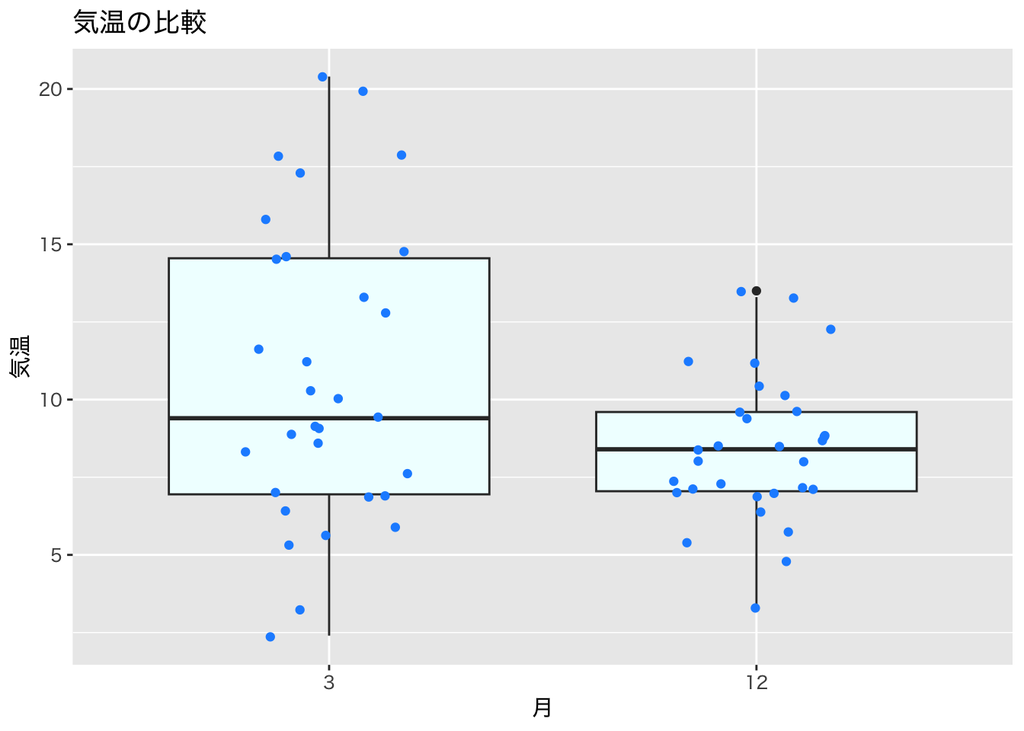

```r
tw_data |>
    filter(month %in% c(3,12)) |>
    ggplot(aes(x = month, y = temp)) +
    geom_boxplot(fill = "azure") + # 色を変える
    geom_jitter(colour = "dodgerblue", width = 0.2) +
    labs(x = "月", y = "気温", title = "気温の比較")
```

平均気温は似通っているがばらつきは異なるように見える．

```r
x <- tw_data |> filter(month == 3) |> pull(temp)
y <- tw_data |> filter(month == 12) |> pull(temp)
var.test(x,y)
```

```
    F test to compare two variances

data:  x and y
F = 4.2703, num df = 30, denom df = 30, p-value = 0.0001514
alternative hypothesis: true ratio of variances is not equal to 1
95 percent confidence interval:
 2.059011 8.856307
sample estimates:
ratio of variances
          4.270274
```